# Workshop 04. The Developer’s Toolbox & AI

Kira Roberts

2026-05-27

## Introduction

#### Workspace: D:/1Techniques/Programing_intro/Programing_intro.Rproj

This document contains the code needed for the fourth workshop in the MB5370 “Introduction to Programming” module.

With the rise of AI tools and their strong ability to aid in coding, this workshop looked at integrating AI into our systems. AI helps handle the syntax aspect of coding, which allows us to focus on the biological and statistical logic of our work. We integrated *GitHub Copilot* for an in code auto-completer, and *chattr* to help with troubleshooting.

The following is a record of what was undertaken and any code necessary for this. Most code was run through the console with some exceptions in the terminal. This file should not be run as is.

## Copilot

As students, GitHub allows us free access to their Copilot as part of their educational program but outside of this, it is a paid service. But once linked to your account, activating it in RStudio is quick and easy. Under the *Tools* tab at the top, select *Global Options* then *Assistant*. From there you can sign in and copy over the verification code that is provided.A GitHub authorization window will open in your browser, and you must paste the code you copied there. After this you can should now have it installed. You can toggle it on and off through the same assistant tab from before.

### Using Predictive Text

Using the Palmer Penguins dataset and Copilots predictive text, we will revisit some of the visualization techniques from the second workshop.

With copilot active, I entered the following commands, accepting the prompts *Load tidyverse and palmerpenguins libraries* *Create a ggplot scatter plot using the penguins dataset.* *Plot bill_length_mm on the x-axis and bill_depth_mm on the y-axis.* *Color points by species and use geom_point with size 3.* *Add a minimal theme and clean labels.* *Generate a boxplot that compares flipper_length_mm across the different species.* *Facet this by island, using custom color palettes.*

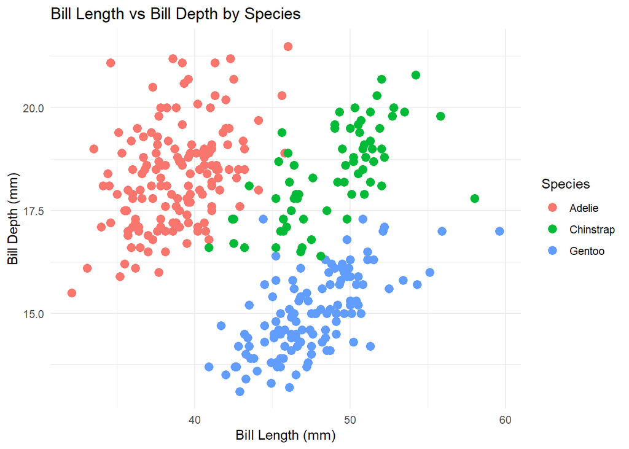

```r
# Load tidyverse and palmerpenguins libraries
library(tidyverse)
library(palmerpenguins)
# Create a ggplot scatter plot using the penguins dataset.
ggplot(data = penguins, aes(x = bill_length_mm, y = bill_depth_mm)) +
  geom_point(aes(color = species), size = 3) +
  theme_minimal() +
  labs(title = "Bill Length vs Bill Depth by Species",
       x = "Bill Length (mm)",
       y = "Bill Depth (mm)",
       color = "Species")
```

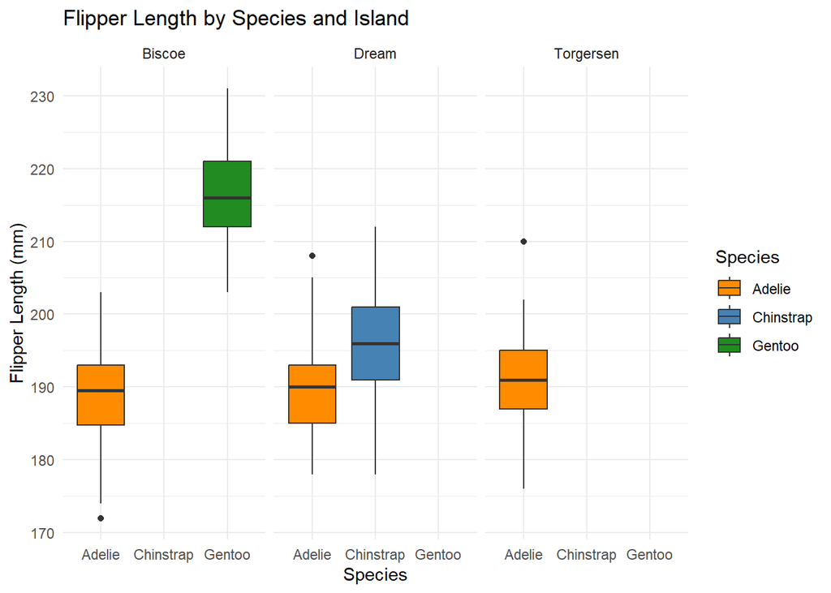

```r
# Generate a boxplot that compares flipper_length_mm across the different species. Facet this by island, using custom color palettes.
ggplot(data = penguins, aes(x = species, y = flipper_length_mm, fill = species)) +
  geom_boxplot() +
  facet_wrap(~ island) +
  scale_fill_manual(values = c("darkorange", "steelblue", "forestgreen")) +
  theme_minimal() +
  labs(title = "Flipper Length by Species and Island",
       x = "Species",
       y = "Flipper Length (mm)",
       fill = "Species")
```

## Chattr

```r
install.packages("ellmer")
install.packages("chattr")
usethis::edit_r_environ()
usethis::edit_r_profile()
```

set shortcut to open chat to “ctrl + alt + c”

## if and else

```r
# Simple Example: Checking Sea Surface Temperature (SST)

sst <- 30.2

if (sst > 29.5) {
  print("Warning: Marine heatwave threshold exceeded!")
} else {
  print("SST remains within baseline parameters.")
}
```

```
## [1] "Warning: Marine heatwave threshold exceeded!"
```

## if_else

```r
# Load tidyverse (if not already loaded)
library(tidyverse)

# Sample coral data
coral_monitoring <- tibble(
  site = c("Site_A", "Site_B", "Site_C"),
  depth_m = c(12, 35, 8)
)

# Classify depth using if_else
coral_monitoring <- coral_monitoring %>%
  mutate(zone = if_else(depth_m > 30, "Deep Reef", "Shallow Reef"))
```

## Task: Mutations and Pipes

*What do you think that function mutate() does? How can we get more information about it? What about the %>% symbol? Use your developing programmer skills to find out more information about these two functions and record your findings now in your qmd.*

Mutate add/modifys a column, in this particular situation it adds a column based on whether the depth_m column is greater than 30m. If it is, this section of code adds a new data point in the new column (Zone) that classifies it as a Deep reef and if it is less than 30m, it is classifies it as a shallow reef. The %>% symbol is a pipeline, it connects sections of code together.

## case_when()

```r
coral_monitoring <- coral_monitoring %>%
  mutate(reef_category = case_when(
    depth_m < 10  ~ "Lagoon / Flats",
    depth_m <= 30 ~ "Crest / Slope",
    depth_m > 30  ~ "Mesophotic / Deep",
    TRUE          ~ "Unclassified" # Catch-all remainder
  ))
```

## Task: Environmental Stress Classification

*Using the chattr app or inline copilot, your task here is to write an R script that initialises a tibble named marine_stations containing a column for salinity with values 35, 28, 32, and 12. Use the pipe operator (%>%) and mutate() combined with case_when() to create a new column named environment_type. Classify values below 15 as “Estuarine”, values between 15 and 30 as “Brackish”, and values above 30 as “Marine”. Run your script and verify the table structure.*

## Loops

```r
# Classic loop anatomy
for (year in 2020:2024) {
  print(paste("Processing climate data for year:", year))
}
```

```
## [1] "Processing climate data for year: 2020"
## [1] "Processing climate data for year: 2021"
## [1] "Processing climate data for year: 2022"
## [1] "Processing climate data for year: 2023"
## [1] "Processing climate data for year: 2024"
```

```r
# Loop across index sequences
transect_lengths <- c(50, 100, 25, 75)

for (i in seq_along(transect_lengths)) {
  print(paste("Transect number", i, "measures", transect_lengths[i], "metres."))
}
```

```
## [1] "Transect number 1 measures 50 metres."
## [1] "Transect number 2 measures 100 metres."
## [1] "Transect number 3 measures 25 metres."
## [1] "Transect number 4 measures 75 metres."
```

## Comparison Example: Calculating Square Roots of Site Vectors

Using a standard for-loop:

```r
site_areas <- c(144, 400, 625)
results <- numeric(length(site_areas)) # Must build an empty container first

for(i in seq_along(site_areas)){
  results[i] <- sqrt(site_areas[i])
}
```

Using the purrr equivalent:

```r
library(purrr)
# Map directly and define your expected output type explicitly
mapped_results <- map_dbl(site_areas, sqrt)
```

You can combine purrr pipelines seamlessly inside data frames to split analysis across separate groups:

```r
# Iterate a summary function over split lists of data
iris %>%
  split(.$Species) %>%
  map(~summary(.x))
```

```
## $setosa
##   Sepal.Length    Sepal.Width     Petal.Length    Petal.Width
##  Min.   :4.300   Min.   :2.300   Min.   :1.000   Min.   :0.100
##  1st Qu.:4.800   1st Qu.:3.200   1st Qu.:1.400   1st Qu.:0.200
##  Median :5.000   Median :3.400   Median :1.500   Median :0.200
##  Mean   :5.006   Mean   :3.428   Mean   :1.462   Mean   :0.246
##  3rd Qu.:5.200   3rd Qu.:3.675   3rd Qu.:1.575   3rd Qu.:0.300
##  Max.   :5.800   Max.   :4.400   Max.   :1.900   Max.   :0.600
##        Species
##  setosa    :50
##  versicolor: 0
##  virginica : 0
##
##
##
##
## $versicolor
##   Sepal.Length    Sepal.Width     Petal.Length   Petal.Width          Species
##  Min.   :4.900   Min.   :2.000   Min.   :3.00   Min.   :1.000   setosa    : 0
##  1st Qu.:5.600   1st Qu.:2.525   1st Qu.:4.00   1st Qu.:1.200   versicolor:50
##  Median :5.900   Median :2.800   Median :4.35   Median :1.300   virginica : 0
##  Mean   :5.936   Mean   :2.770   Mean   :4.26   Mean   :1.326
##  3rd Qu.:6.300   3rd Qu.:3.000   3rd Qu.:4.60   3rd Qu.:1.500
##  Max.   :7.000   Max.   :3.400   Max.   :5.10   Max.   :1.800
##
## $virginica
##   Sepal.Length    Sepal.Width     Petal.Length    Petal.Width
##  Min.   :4.900   Min.   :2.200   Min.   :4.500   Min.   :1.400
##  1st Qu.:6.225   1st Qu.:2.800   1st Qu.:5.100   1st Qu.:1.800
##  Median :6.500   Median :3.000   Median :5.550   Median :2.000
##  Mean   :6.588   Mean   :2.974   Mean   :5.552   Mean   :2.026
##  3rd Qu.:6.900   3rd Qu.:3.175   3rd Qu.:5.875   3rd Qu.:2.300
##  Max.   :7.900   Max.   :3.800   Max.   :6.900   Max.   :2.500
##        Species
##  setosa    : 0
##  versicolor: 0
##  virginica :50
##
##
##
```

## Task using chattr:

*Use chattr to convert a complex operation. Prompt the engine: “I have a list of three vectors containing fish count data. Write a for-loop to calculate the mean of each, and then show me the exact parallel way to do it using purrr’s map_dbl function.” Compare the visual simplicity.* My code given is below

```r
# Example fish count vectors
fish1 <- c(12, 15, 18, 20)
fish2 <- c(5, 7, 9, 6)
fish3 <- c(30, 28, 35, 40)

# Put them into a list
fish_counts <- list(fish1, fish2, fish3)


# Using a for-loop
# Empty vector to store means
mean_counts <- numeric(length(fish_counts))

# For-loop
for(i in seq_along(fish_counts)) {
  mean_counts[i] <- mean(fish_counts[[i]])
}

mean_counts
```

```
## [1] 16.25  6.75 33.25
```

```r
# Using Purrr
library(purrr)

mean_countsP <- map_dbl(fish_counts, mean)

mean_countsP
```

```
## [1] 16.25  6.75 33.25
```

## Writing custom functions

When you find yourself copying and pasting the exact same block of logical code or loop transformations three or more times, it is time to write a custom function. Functions package your logic into clear, named, reusable assets

## Function Construction Blueprint

A function consists of a Name, Arguments (the input variables), and a Body (the execution logic wrapped inside curly braces).

```r
# Function Definition
calculate_coral_mortality <- function(initial_count, surviving_count) {

  # Logic safety switch using our conditional tools!
  if (initial_count <= 0) {
    stop("Initial count must be greater than zero.")
  }

  mortality_rate <- (initial_count - surviving_count) / initial_count
  return(mortality_rate)
}

# Utilizing your custom function
calculate_coral_mortality(initial_count = 120, surviving_count = 84)
```

```
## [1] 0.3
```

Best Practice Rule: Always test your functions in a clean local environment. Ensure they rely strictly on the arguments passed directly into them, rather than accidentally grabbing random background objects floating in your global R environment.

## Task: Custom Function Construction Task

*Build a custom function named convert_temp_c_to_f that accepts a single argument representing temperature in Celsius. The function should perform the math conversion: F = (C x 9/5) + 32. Include a conditional safety check using an if statement that halts execution via stop() if the entered value is below absolute zero (-273.15 degrees Celsius). Test your function with both a valid temperature and an invalid value to ensure the error handling behaves as expected.*

```r
temp_CtoF <- function(temp_C) {
  if (temp_C < -273.15) {
    stop("Temperature cannot be below absolute zero (-273.15°C).")
  }
  fahrenheit <- (temp_C * 9/5) + 32
  return(fahrenheit)
}

# Valid temp
temp_CtoF(28)
```

```
## [1] 82.4
```

```r
# Invalid temp
#temp_CtoF(-279)

# Output for invalid temp below, code was commented out to allow knitting
#Error in temp_CtoF(-279) :
#Temperature cannot be below absolute zero (-273.15°C).
```